# Incarceration Trends

Mayumi Sophiya Alino

**This project seeks to analyze incarceration data from The Vera Project to analyze the trends of race and incarceration. The variables being compared and analyzed in this project are by county and include such information as jail and prison population, pre-trial population, etc. I have also computed additional values such as the ratio of jail/prison population by race over the total jail/prison population. Because of the American history and reality of slavery, colonization, imperialism, and policing over Black populations the visualizations covered in this project specify mainly on the Black population**

[output not shown]

[output cut: 30178 more lines]

This dataset answers my questions of analysis such as: -How much of each race is in jail/prison compared to the overall population? (i.e, what do the jails look like in terms of race?) *note that the total incarcerated population were not included in this question, as it would have equaled 1. -where is each race incarcerated more? (i.e, are they more likely to be in jail or in prison?) -the total ratio of each race in jail AND prison -how much of each racial community is in jail/prison? (i.e, the ratio of incarcerated community members in proportion to their community instead of the whole population)

Trends over time chart

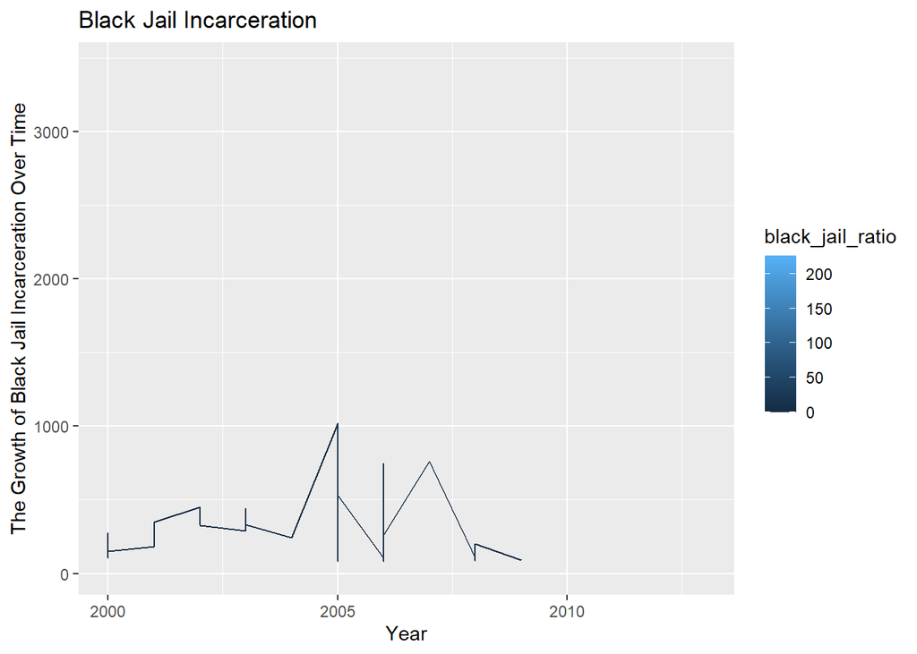

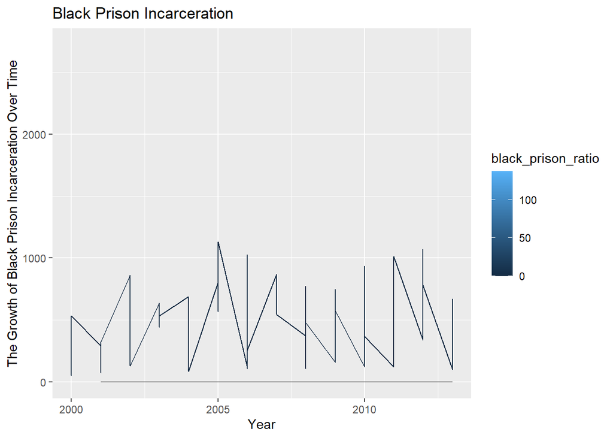

These charts are included to analyze the ratio of black incarceration by year (the ratio of black jail/prison population over the total jail/prison population), showing more fluctuations in the prison data than the jail data. Overall there is a peak in both graphs at 2005.

Variable comparison chart

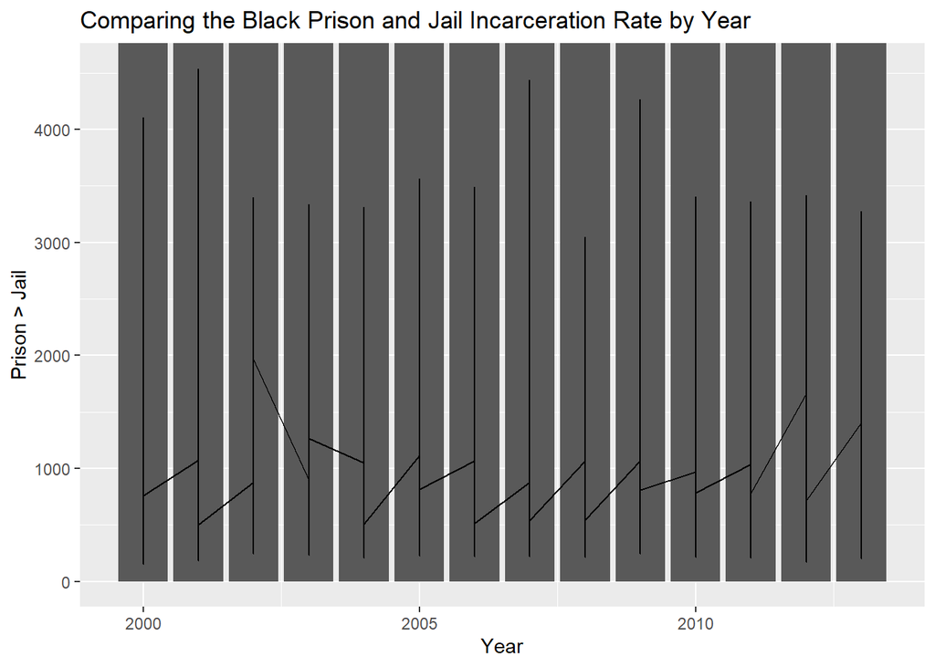

Map

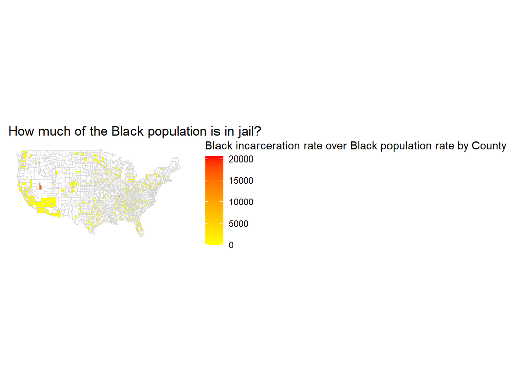

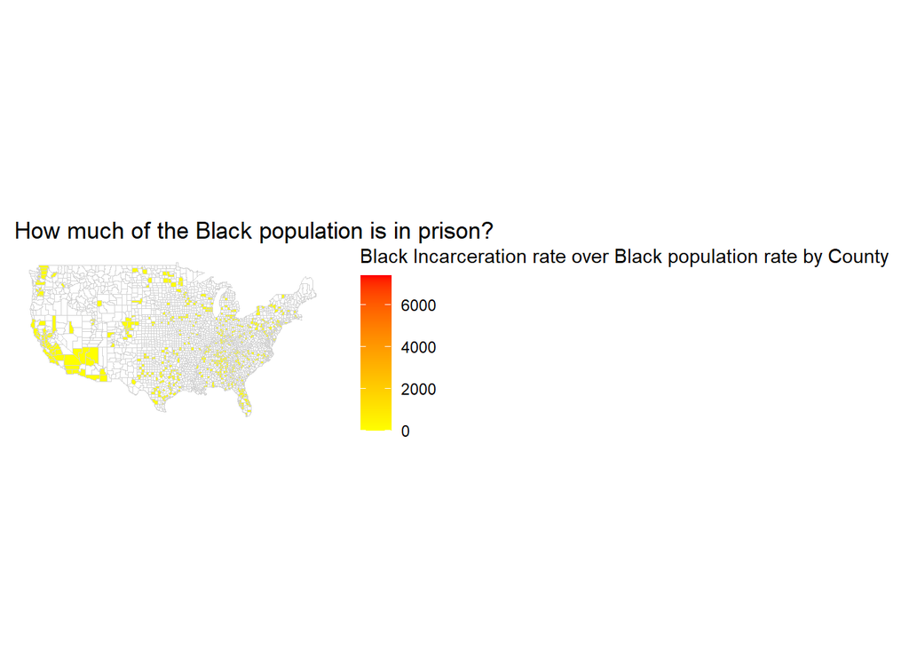

This map shows, per county, in which areas of the country is the black community more heavily incarcerated, divided by prison and jail. The computed data is the ratio of incarcerated black population over the total black population (i.e, how much of the black community is incarcerated?) There have been data on the ratio of black incarceration rates over the total population as well as in comparison to other races, but in order to contextualize just how disproportionate this imprisonment is the data calculated in this project is on how much of this race is incarcerated.